# STA 601/360 Homework 6

Yifei Wang

17 October, 2019

### 1. Hoff problem 6.1 Poisson population comparisons

I first derive the joint distribution of all the parameters,

$$p(\theta, \gamma, \mathbf y_A, \mathbf y_B) = p(\theta) \, p(\gamma) \, p(\mathbf y_A | \theta) \, p(\mathbf y_B | \theta, \gamma)$$

#### (a) Are $\theta_A$ and $\theta_B$ independent or dependent under this prior distribution? In what situations is such a joint prior distribution justified?

We have

$$\begin{aligned}
\mathbb E[\theta_A] &= \mathbb E[\theta] = \frac{a_{\theta}}{b_{\theta}} \\
\mathbb E[\theta_B] &= \mathbb E[\theta \gamma] = \mathbb E[\theta] \mathbb E[\gamma] = \frac{a_{\theta}}{b_{\theta}} \frac{a_{\gamma}}{b_{\gamma}} \\
\mathbb E[\theta_A\theta_B] &= \mathbb E[\theta^2 \gamma] = \mathbb E[\theta^2] \mathbb E[\gamma] = \frac{a_{\theta}+a_{\theta}^2}{b_{\theta}^2} \frac{a_{\gamma}}{b_{\gamma}} \neq \mathbb E[\theta_A]\mathbb E[\theta_B]
\end{aligned}$$

Thus, $\theta_A$ and $\theta_B$ are dependent under this prior distribution. This joint prior distribution justified only when the true $\theta_A$ is proportional to $\theta_B$.

#### (b) Obtain the form of the full conditional distribution of $\theta$ given $\mathbf y_A$, $\mathbf y_B$ and $\gamma$.

$$\begin{aligned}
p(\theta | \mathbf y_A, \mathbf y_B, \gamma)
&\propto p(\mathbf y_A | \mathbf y_B, \theta, \gamma) \, p(\theta | \mathbf y_B, \gamma) \\
&\propto p(\mathbf y_A | \mathbf y_B, \theta, \gamma) \, p(\mathbf y_B | \theta, \gamma) \, p(\theta | \gamma) \\
&= p(\mathbf y_A | \theta) \, p(\mathbf y_B | \theta, \gamma) \, p(\theta) \\
&= p(\theta) \prod_{i=1}^{n_A} p(y_i | \theta) \, \prod_{j=1}^{n_B} p(y_j | \theta, \gamma) \\
&\propto \theta^{a_{\theta}-1} e^{-\beta_{\theta}\theta} \prod_{i=1}^{n_A} \theta^{y_i} e^{-\theta} \, \prod_{j=1}^{n_B} \theta^{y_j} e^{-\gamma\theta} \\
&= \theta^{\sum_{i=1}^{n_A} y_i+\sum_{j=1}^{n_B} y_j+a_{\theta}-1} e^{-(b_{\theta}+n_A+n_B\gamma)\theta}
\end{aligned}$$

Using the kernel trick, we know that

$$\theta | \mathbf y_A, \mathbf y_B, \gamma \sim \text{Gamma}(\sum_{i=1}^{n_A} y_i+\sum_{j=1}^{n_B} y_j+a_{\theta},\, b_{\theta}+n_A+n_B\gamma)$$

#### (c) Obtain the form of the full conditional distribution of $\gamma$ given $y_A$, $y_B$ and $\theta$.

$$\begin{aligned}
p(\gamma | \mathbf y_A, \mathbf y_B, \theta)
&\propto p(\mathbf y_B | \mathbf y_A, \theta, \gamma) \, p(\gamma | \mathbf y_A, \theta) \\
&\propto p(\mathbf y_B | \mathbf y_A, \theta, \gamma) \, p(\mathbf y_A | \gamma, \theta) \, p(\gamma | \theta) \\
&= p(\mathbf y_B | \theta, \gamma) \, p(\mathbf y_A | \theta) \, p(\gamma) \\
&\propto \gamma^{a_{\gamma}-1} e^{-b_{\gamma}\gamma} \prod_{i=1}^{n_B} \gamma^{y_i} e^{-\theta\gamma} \\
&= \gamma^{\sum_{i=1}^{n_B} y_i + a_{\gamma} - 1} \, e^{-(n\theta + b_{\gamma})\gamma}
\end{aligned}$$

Using the kernel trick, we know that,

$$\gamma | \mathbf y_A, \mathbf y_B, \theta \sim \text{Gamma}(\sum_{i=1}^{n_B} y_i + a_{\gamma}, n_B\theta + b_{\gamma})$$

#### (d) Set $a_{\theta} = 2$ and $b_{\theta} = 1$. Let $a_{\gamma} = b_{\gamma} \in \{8,16,32,64,128\}$. For each of these five values, run a Gibbs sampler of at least 5,000 iterations and obtain $\mathbb E [\theta_B - \theta_A | \mathbf{y}_A, \mathbf{y}_B]$. Describe the effects of the prior distribution for $\gamma$ on the results.

```r
# data and prior
men_A = scan("menchild30bach.dat")
men_B = scan("menchild30nobach.dat")
sum_A = sum(men_A)
sum_B = sum(men_B)
n_A = length(men_A)
n_B = length(men_B)

a_theta = 2
b_theta = 1
ab_gamma = c(8, 16, 32, 64, 128)
m = length(ab_gamma)
S = 5000
```

```r
# starting point
theta_0 = a_theta / b_theta
gamma_0 = 1
gibbs_theta = matrix(nrow = m, ncol = S + 1)
gibbs_gamma = matrix(nrow = m, ncol = S + 1)
gibbs_theta[,1] = theta_0
gibbs_gamma[,1] = gamma_0
```

```r
# gibbs sampler
for (s in 2:(S+1)) {
  gibbs_theta[,s] = rgamma(m, shape = sum_A + sum_B + a_theta,
                           rate = n_A + n_B * gibbs_gamma[,s-1] + b_theta)
  gibbs_gamma[,s] = rgamma(m, shape = sum_B + ab_gamma,
                           rate = n_B * gibbs_theta[,s] + ab_gamma)
}
```

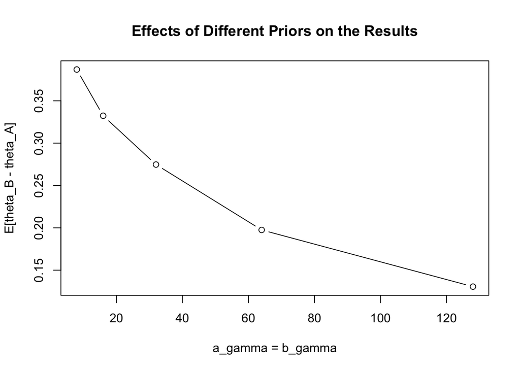

```r
# analysis
theta_A = gibbs_theta
theta_B = gibbs_theta * gibbs_gamma

E_BmA = rowMeans(theta_B - theta_A)
plot(ab_gamma, E_BmA, "b",
     xlab = "a_gamma = b_gamma",
     ylab = "E[theta_B - theta_A]",
     main = "Effects of Different Priors on the Results")
```

The plot shows that the expectation of the difference between $\theta_B$ and $\theta_A$ shrinkages to 0 when $a_{\gamma}$ and $b_{\gamma}$ increases towards infinity. This could be seen from the posterior mean of $\gamma$. We know that $\frac{\theta_B}{\theta_A} = \gamma$ and the posterior mean of $\gamma$ is

$$\frac{\sum_{i=1}^{n_B} y_i + a_{\gamma}}{n_B\theta + b_{\gamma}} = \frac{n_B}{n_B\theta + b_{\gamma}} \frac{\sum_{i=1}^{n_B} y_i}{n_B} + \frac{b_{\gamma}}{n_B\theta + b_{\gamma}} \frac{a_{\gamma}}{b_{\gamma}}$$

and this converges to 1 when prior sample sizes $a_{\gamma} = b_{\gamma} \to \infty$. This makes $\mathbb E(\theta_B | \mathbf y_A, \mathbf y_B) = \mathbb E(\theta_A | \mathbf y_A, \mathbf y_B)$ and thus $\mathbb E(\theta_B - \theta_A | \mathbf y_A, \mathbf y_B) = 0$.

### 2. Hoff problem 6.3

To help tackle the problem, I first derive and factorize the joint distribution for all parameters.

$$p(x, y, z, c, \beta, \tau_{\beta}^2, \tau_{c}^2) = p(y | z, c) \, p(z|\beta, x) \, p(\beta|\tau_{\beta}^2) \, p(c|\tau_{c}^2) \, p(x)$$

#### (a) Assuming $\beta \sim \text{Normal}(0, \tau_{\beta}^2)$ obtain the full conditional distribution $p(\beta | \mathbf y, \mathbf x, \mathbf z, c)$.

$$\begin{aligned}
p(\beta | \mathbf y, \mathbf x, \mathbf z, c)
&\propto p(\mathbf z|\mathbf x, \mathbf y, \beta, c) \, p(\beta | \mathbf y, \mathbf x, c) \\
&= p(\mathbf z|\mathbf x, \beta) \, p(\beta) \\
&\propto \prod_{i=1}^{25} \exp \left( -\frac12(z_i - \beta x_i)^2 \right) \, \exp\left( -\frac1{2\tau_{\beta}^2}\beta^2 \right) \\
&= \exp\left(-\frac12\left[(\frac1{\tau_{\beta}^2}+\sum_{i=1}^{25} x_i^2)\beta^2 - 2\beta\sum_{i=1}^{25}x_iz_i\right]\right) \\
&= \exp\left(-\frac12\left[(\frac1{\tau_{\beta}^2}+\mathbf x^T\mathbf x)\beta^2 - 2\beta\mathbf x^T\mathbf z\right]\right) \\
&= \exp\left(-\frac12 (\frac1{\tau_{\beta}^2}+\mathbf x^T\mathbf x) \left(\beta - (\frac1{\tau_{\beta}^2}+\mathbf x^T\mathbf x)^{-1} \mathbf x^T\mathbf z\right)^2\right) \\
&\sim \text{Normal}\left((\frac1{\tau_{\beta}^2}+\mathbf x^T\mathbf x)^{-1} \mathbf x^T\mathbf z\, , \; (\frac1{\tau_{\beta}^2}+\mathbf x^T\mathbf x)^{-1}\right)
\end{aligned}$$

#### (b) Assuming $c \sim \text{Normal}(0, \tau_c^2)$, show that $p(c|\mathbf y, \mathbf x, \mathbf z, \beta)$ is a constrained normal density, i.e. proportional to a normal density but constrained to lie in an interval. Similarly, show that $p(z_i | \mathbf y, \mathbf x, \mathbf z-i, \beta, c)$ is proportional to a normal density but constrained to be either above $c$ or below $c$, depending on $y_i$.

Let $\text{Truncated Normal}(\mu, \sigma^2, a, b)$ be the truncated Normal distribution of $\text{Normal}(\mu, \sigma^2)$ on $[a, b]$. For the full conditional distribution of $c$, we have

$$\begin{aligned}
p(c|\mathbf y, \mathbf x, \mathbf z, \beta)
&\propto p(\mathbf y | \mathbf x, \mathbf z, \beta, c) \, p(c | \mathbf x, \mathbf z, \beta) \\
&= p(\mathbf y | \mathbf z, c) \, p(c) \\
&= \prod_{i=1}^{25} p(y_i | z_i, c) \, p(c) \\
&= \prod_{i=1}^{25} \sigma_{c, \infty}(z_i) \, p(c) \\
&= [\max_{y_i=0}(z_i), \min_{y_i=1}(z_i)] \, p(c)
\end{aligned}$$

so we have,

$$c|\mathbf y, \mathbf x, \mathbf z, \beta \sim \text{Truncated Normal}(0, \tau_{c}^2, \max_{y_i=0}(z_i), \min_{y_i=1}(z_i))$$

We konw that $Z_i = \beta x_i + \epsilon_i$ and $\epsilon_i \sim \text{Normal}(0, 1)$ so we have $Z_i \sim \text{Normal}(\beta x_i, 1)$. As for the full conditional distribution of $\mathbf z$, we know any $z_i$ is independent on $z_j$ for any $j \neq i$. Thus we have

$$\begin{aligned}
p(z_i | \mathbf y, \mathbf x, \mathbf z_{-i}, \beta, c)
&= p(z_i | \mathbf y, \mathbf x, \beta, c) \\
&= p(z_i | y_i, x_i, \beta, c) \\
&\propto p(y_i | z_i, x_i, \beta, c) \, p(z_i | x_i, \beta, c) \\
&= p(y_i | z_i, c) \, p(z_i | x_i, \beta) \\
&= f(z_i)
\end{aligned}$$

where

$$f(z_i) = \begin{cases}
p(z_i | x_i, \beta) [z_i < c] \,,&\text{if }\, y_i = 0 \\
p(z_i | x_i, \beta) [z_i > c] \,,&\text{if }\, y_i = 1
\end{cases}$$

and

$$\begin{aligned}
z_i \mid y_i = 0 &\;\sim\; \text{Truncated Normal}(\beta x_i, 1, -\infty, c) \\
z_i \mid y_i = 1 &\;\sim\; \text{Truncated Normal}(\beta x_i, 1, c, \infty)
\end{aligned}$$

#### (c) Letting $\tau_{\beta}^2 = \tau_c^2 = 16$, implement a Gibbs sampling scheme that approximates the joint posterior distribution of $Z$, $\beta$, and $c$ (a method for sampling from constrained normal distributions is outlined in Section 12.1.1). Run the Gibbs sampler long enough so that the effective sample sizes of all unknown parameters are greater than 1,000 (including the $Z_i$’s). Compute the autocorrelation function of the parameters and discuss the mixing of the Markov chain.

```r
# data and priors
set.seed(323)
library(truncnorm)
library(coda)
xy = scan("divorce.dat")
x = xy[seq(1, 49, 2)]
y = xy[seq(2, 50, 2)]

tau_b = tau_c = 4
beta_sigma2 = 1 / (1/tau_b^2 + sum(x^2))
S = 50000

gibbs_beta = vector(mode = "numeric", length = S + 1)
gibbs_c = vector(mode = "numeric", length = S + 1)
gibbs_z = matrix(nrow = length(x), ncol = S + 1)

# full conditional distribution
rc_gibbs = function(y, z) {
  a = max(z[y==0])
  b = min(z[y==1])
  c = rtruncnorm(1, a = a, b = b, mean = 0, sd = tau_c^2)
  return(c)
}
rz_gibbs = function(x, y, beta, c) {
  z_y0 = (1 - y) * rtruncnorm(25, b = c, mean = beta*x, sd = 1)
  z_y1 = y * rtruncnorm(25, a = c, mean = beta*x, sd = 1)
  return(z_y0 + z_y1)
}

# starting point
gibbs_beta_0 = 0
gibbs_c_0 = 0
gibbs_z_0 = rz_gibbs(x = x, y = y, beta = gibbs_beta_0, c = gibbs_c_0)
gibbs_beta[1] = gibbs_beta_0
gibbs_c[1] = gibbs_c_0
gibbs_z[, 1] = gibbs_z_0

# gibbs sampler
for (s in 2:(S+1)) {
  beta_mu = beta_sigma2 * sum(x*gibbs_z[,s-1])
  gibbs_beta[s] = rnorm(1, mean = beta_mu, sd = sqrt(beta_sigma2))
  gibbs_c[s] = rc_gibbs(y = y, z = gibbs_z[,s-1])
  gibbs_z[, s] = rz_gibbs(x = x, y = y, beta = gibbs_beta[s], c = gibbs_c[s])
}
```

```r
# effective sizes
es = data.frame(parameter = vector(length = 25), EffectiveSize = vector(length = 25), geq1000 = vector(length = 25))
es[1,] = c("beta", floor(effectiveSize(gibbs_beta)), 0)
es[2,] = c("c", floor(effectiveSize(gibbs_c)), 0)
for (i in 1:25) {
  es[i+2,] = c(paste("z", i, sep="_"), floor(effectiveSize(gibbs_z[i,])), 0)
}
es$geq1000 = es$EffectiveSize > 1000
es
```

```
##    parameter EffectiveSize geq1000
## 1       beta          2860    TRUE
## 2          c          1836    TRUE
## 3        z_1          8790    TRUE
## 4        z_2         27761    TRUE
## 5        z_3         27094    TRUE
## 6        z_4         13472    TRUE
## 7        z_5         25579    TRUE
## 8        z_6         42664    TRUE
## 9        z_7          6230    TRUE
## 10       z_8          4026    TRUE
## 11       z_9         24875    TRUE
## 12      z_10          8734    TRUE
## 13      z_11         37592    TRUE
## 14      z_12          8249    TRUE
## 15      z_13          5399    TRUE
## 16      z_14          7859    TRUE
## 17      z_15          6668    TRUE
## 18      z_16         40762    TRUE
## 19      z_17          7252    TRUE
## 20      z_18          8672    TRUE
## 21      z_19         26773    TRUE
## 22      z_20         25726    TRUE
## 23      z_21          8055    TRUE
## 24      z_22         25511    TRUE
## 25      z_23          6430    TRUE
## 26      z_24          3392    TRUE
## 27      z_25         16931    TRUE
```

For the diagnositc of autocorrelation and the analysis of mixing of the Markov Chains, I choose parameter $c$, $\beta$, $z_{24}$ and $z_6$ to focus on. All the $z_i$ are independent of each other and $z_{24}$ has the smallest effective size while $z_6$ has the greatest effective size. They could represent the autocorrelation and mixing characteristics of these chains. Additionally, the same methods could be easily applied to other parameters of interest.

```r
# autocorrelation
autocorr.diag(as.mcmc(gibbs_beta)) # autocorrelation of different lag values
```

```
##              [,1]
## Lag 0  1.00000000
## Lag 1  0.85105072
## Lag 5  0.50090802
## Lag 10 0.29913686
## Lag 50 0.02358467
```

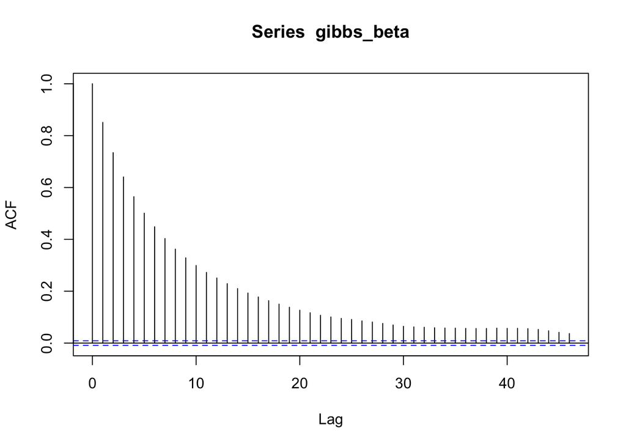

```r
acf(gibbs_beta) # acf plots the decrease of autocorrelation when lag increases
```

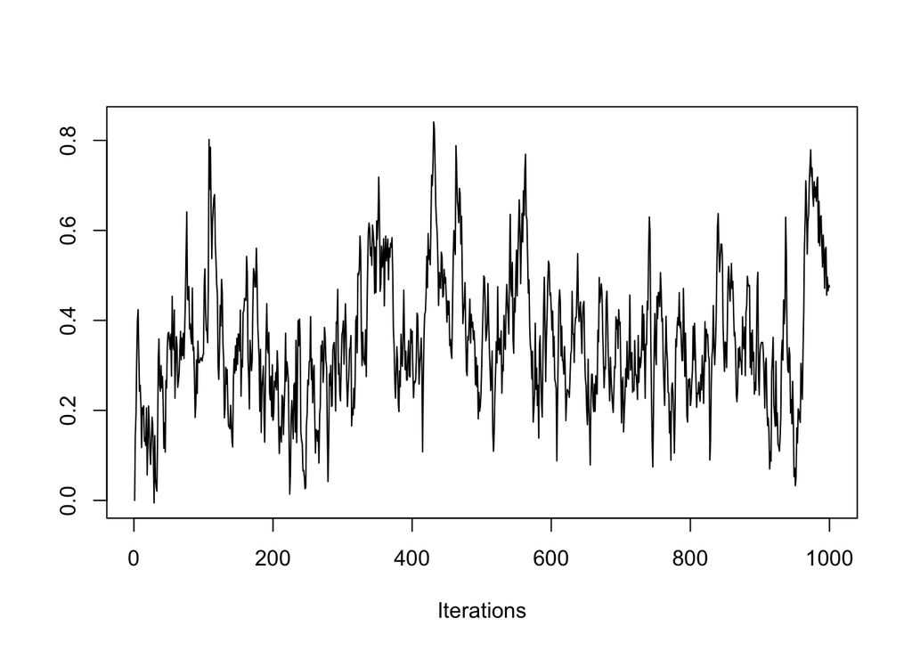

```r
traceplot(as.mcmc(gibbs_beta[1:1000])) # traceplots shows the mixing of mcmc
```

```r
autocorr.diag(as.mcmc(gibbs_c)) # autocorrelation of different lag values
```

```
##              [,1]
## Lag 0  1.00000000
## Lag 1  0.92393182
## Lag 5  0.68658180
## Lag 10 0.47761489
## Lag 50 0.01686816
```

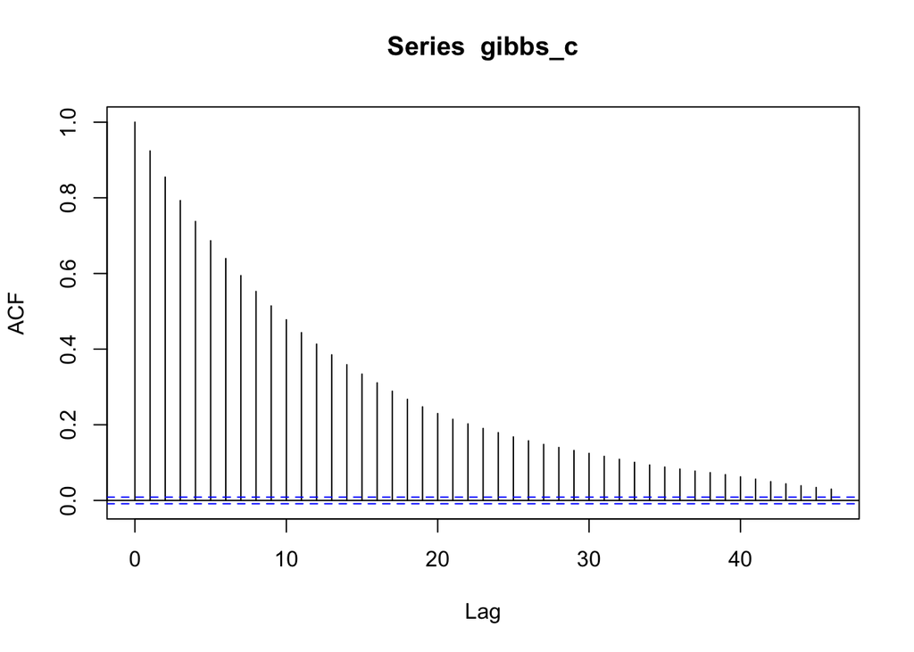

```r
acf(gibbs_c) # acf plots the decrease of autocorrelation when lag increases
```

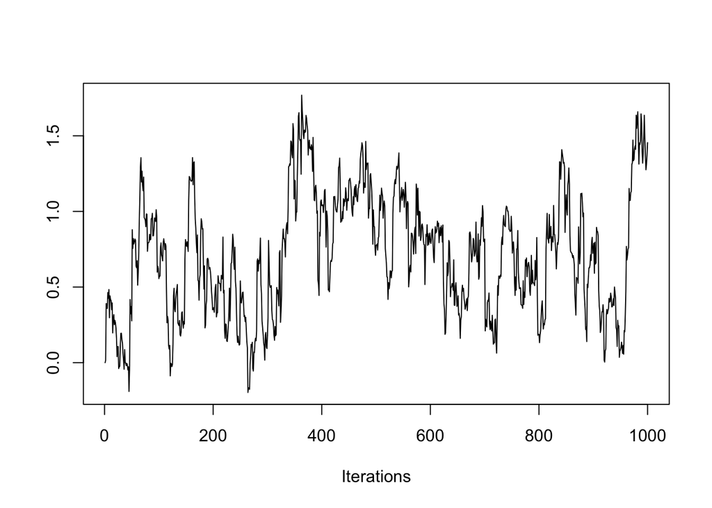

```r
traceplot(as.mcmc(gibbs_c[1:1000])) # traceplots shows the mixing of mcmc
```

```r
autocorr.diag(as.mcmc(gibbs_z[6,])) # autocorrelation of different lag values
```

```
##               [,1]
## Lag 0  1.000000000
## Lag 1  0.021038848
## Lag 5  0.010985188
## Lag 10 0.002051234
## Lag 50 0.005900345
```

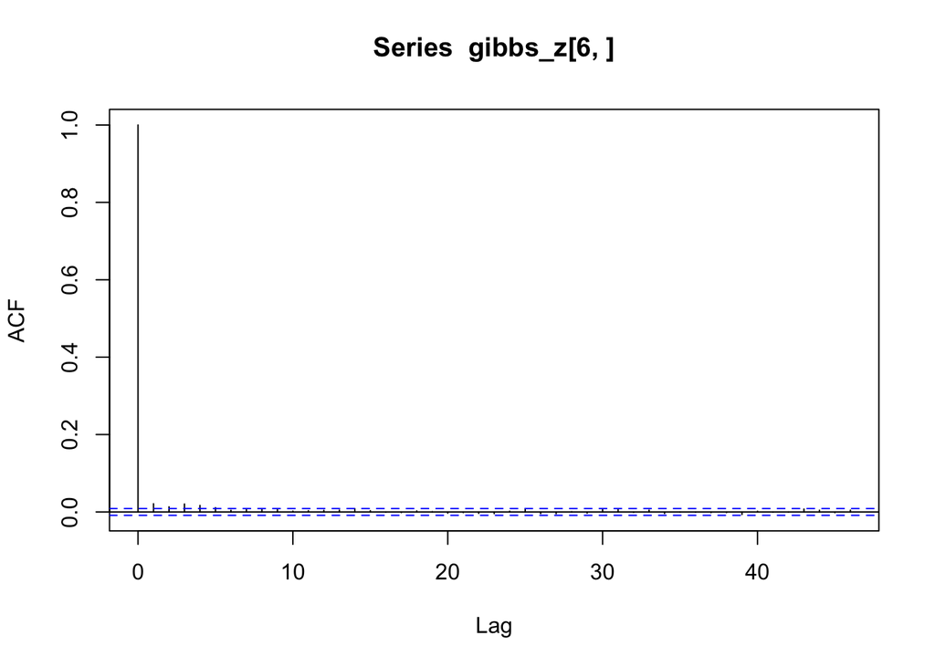

```r
acf(gibbs_z[6,]) # acf plots the decrease of autocorrelation when lag increases
```

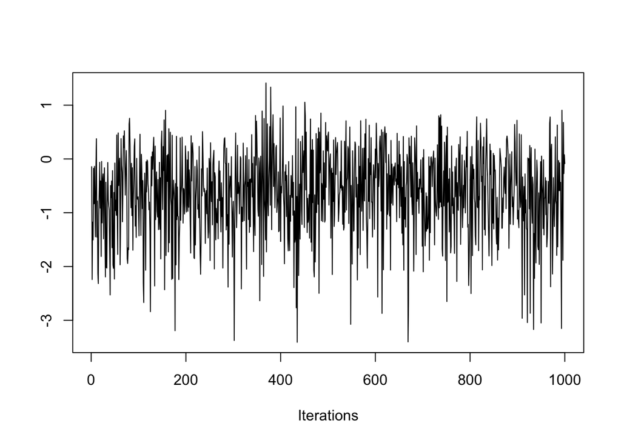

```r
traceplot(as.mcmc(gibbs_z[6,1:1000])) # traceplots shows the mixing of mcmc
```

```r
autocorr.diag(as.mcmc(gibbs_z[24,])) # autocorrelation of different lag values
```

```
##              [,1]
## Lag 0  1.00000000
## Lag 1  0.74142925
## Lag 5  0.42856777
## Lag 10 0.25016098
## Lag 50 0.01547791
```

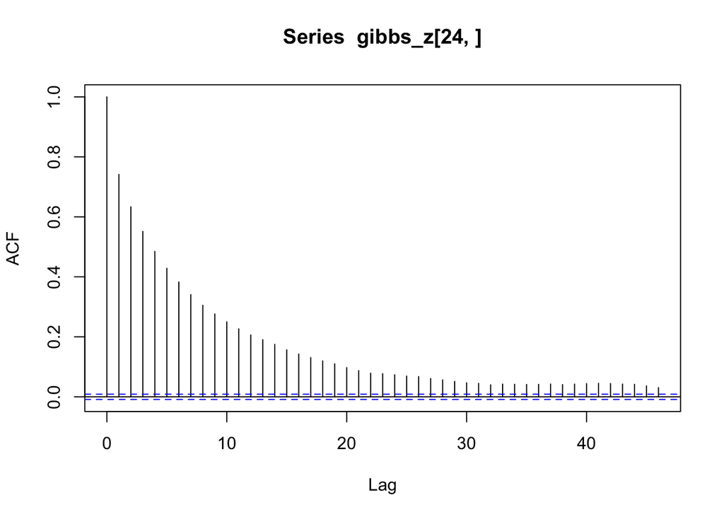

```r
acf(gibbs_z[24,]) # acf plots the decrease of autocorrelation when lag increases
```

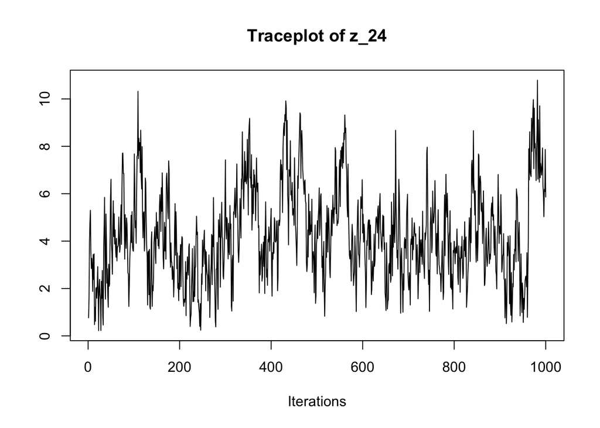

```r
traceplot(as.mcmc(gibbs_z[24,1:1000]), main = "Traceplot of z_24") # traceplots shows the mixing of mcmc
```

From the tables and plots above we can tell that

1. Chains with smaller effective size offen has a more severe mixing and autocorrelation problem.
2. Parameter $c$ has the smallest effective size and the most severe mixing and autocorrelation problemx. Its lag-10 autocorrelation is still 0.48. The “bouncing” ability shown in the traceplot is bad, which also indicates a high autocorrelation. The chain seems to quickly reach the stationary area of the posterior distribution.
3. Parameter $\beta$ also has a small effective size and severe mixing and autocorrelation problemx. Its lag-10 autocorrelation is still 0.30. The “bouncing” ability shown in the traceplot is not good, which also indicates a high autocorrelation. The chain seems to quickly reach the stationary area of the posterior distribution.
4. Parameter $z_i$ in general has large effective sizes and the values vary among different $i$. It seems that the effective sizes of $z_i$ when $y_i = 1$ is generally smaller than those of $z_j$ when $y_j = 0$. In general, the mixing and autocorrelation problem is not that bad for all the $z_i$’s. The lag-10 autocorrelation is 0.002 for $z_6$ and 0.25 for $z_{24}$. The “bouncing” ability shown in the traceplot are good for $z_6$ and not that great for $z_{24}$, which also indicates a high autocorrelation for $z_{24}$. Both chains seem to quickly reach the stationary area of the posterior distribution.

#### (d) Obtain a 95% posterior confidence interval for $\beta$, as well as $\text{Pr}(\beta > 0 | y, x)$.

```r
# 95% posterior confidence interval for beta
quantile(gibbs_beta, probs = c(0.025, 0.975))
```

```
##      2.5%     97.5%
## 0.1011909 0.6535880
```

```r
# posterior probability of beta > 0
mean(gibbs_beta > 0)
```

```
## [1] 0.999
```

### 3. Hoff problem 7.3

#### (a) For each of the two species, obtain posterior distributions of the population mean $\theta$ and covariance matrix $\Sigma$ as follows: Using the semi-conjugate prior distributions for $\theta$ and $\Sigma$, set $\mu_0$ equal to the sample mean of the data, $\Lambda_0$ and $S_0$ equal to the sample covariance matrix and $\nu_0 = 4$. Obtain 10,000 posterior samples of $\theta$ and $\Sigma$. Note that this “prior” distribution loosely centers the parameters around empirical estimates based on the observed data (and is very similar to the unit information prior described in the previous exercise). It cannot be considered as our true prior distribution, as it was derived from the observed data. However, it can be roughly considered as the prior distribution of someone with weak but unbiased information.

For the semi-conjugate priors of $\text{Normal}(\theta, \Sigma)$, we have

$$\begin{aligned}
\theta &\sim \text{Normal}(\mu_0, \Lambda_0) \\
\Sigma &\sim \text{inverse-Wishart}(\nu_0, S_0^{-1})
\end{aligned}$$

Then we have the full conditional posterior distribution

$$\begin{aligned}
\theta | \mathbf y_1, \ldots, \mathbf y_n, \Sigma &\sim \text{Normal}(\mu_n, \Lambda_n) \\
\Sigma | \mathbf y_1, \ldots, \mathbf y_n, \theta &\sim \text{inverse-Wishart}(\nu_0 + n, [S_0 + S_{\theta}]^{-1})
\end{aligned}$$

where

$$\begin{aligned}
\Lambda_n &= (\Lambda_0^{-1} + n\Sigma^{-1})^{-1} \\
\mu_n &= (\Lambda_0^{-1} + n\Sigma^{-1})^{-1} (\Lambda_0^{-1}\mu_0 + n\Sigma^{-1} \mathbf {\bar y}) \\
S_{\theta} &= \sum_{i=1}^n (\mathbf y_i - \theta)(\mathbf y_i - \theta)^T
\end{aligned}$$

```r
# data and priors
set.seed(323)
b = scan("bluecrab.dat")
o = scan("orangecrab.dat")
blue = matrix(nrow = 50, ncol = 2)
orange = matrix(nrow = 50, ncol = 2)
blue[,1] = b[seq(1, 99, 2)]
blue[,2] = b[seq(2, 100, 2)]
orange[,1] = o[seq(1, 99, 2)]
orange[,2] = o[seq(2, 100, 2)]

mu0_blue = colMeans(blue)
mu0_orange = colMeans(orange)
L0_blue = S0_blue = cov(blue)
L0_orange = S0_orange = cov(orange)
nu0 = 4
S = 10000
```

```r
# gibbs sampler
crab_gibbs = function(S, Y, mu0, L0, nu0, S0) {
  n = nrow(Y)
  p = ncol(Y)
  ybar = colMeans(Y)
  THETA = array(dim = c(S, p))
  SIGMA = array(dim = c(S, p, p))
  Sigma = cov(Y)
  for (s in 1:S) {
    # theta
    Ln = solve(solve(L0) + n*solve(Sigma))
    mun = Ln %*% (solve(L0) %*% mu0 + n*solve(Sigma) %*% ybar)
    theta = MASS::mvrnorm(n = 1, mu = mun, Sigma = Ln)

    # Sigma
    Sn = S0 + (t(Y) - c(theta)) %*% t(t(Y) - c(theta))
    Sigma = solve(rWishart(1, nu0 + n, solve(Sn))[,,1])

    # update
    THETA[s,] = theta
    SIGMA[s,,] = Sigma
  }
  return(list(theta = THETA, sigma = SIGMA))
}
```

```r
gibbs_blue = crab_gibbs(S, blue, mu0_blue, L0_blue, nu0, S0_blue)
gibbs_orange = crab_gibbs(S, orange, mu0_orange, L0_orange, nu0, S0_orange)
```

#### (b) Plot values of $\mathbf{\theta} = (\theta_1, \theta2)$ for each group and compare. Describe any size differences between the two groups.

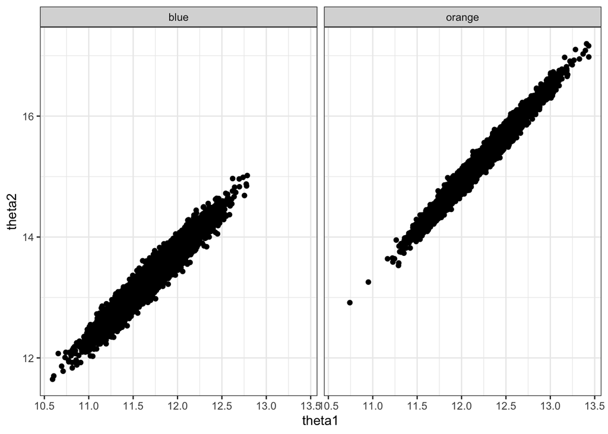

```r
theta_df_blue = data.frame(theta1 = gibbs_blue$theta[, 1], theta2 = gibbs_blue$theta[, 2], types = 'blue')
theta_df_orange = data.frame(theta1 = gibbs_orange$theta[, 1], theta2 = gibbs_orange$theta[, 2], types = 'orange')
theta_df = rbind(theta_df_blue, theta_df_orange)

ggplot(theta_df, aes(x = theta1, y = theta2)) +
  geom_point()+
  facet_wrap(~ types)
```

From the plot above we can tell that both $\theta_1$ and $\theta_2$ in blue crabs are smaller than those in orange crabs with a high probabiliy. This means that the means of both body depth ($Y_1$) and rear width ($Y_2$) of blue crabs are smaller than those of orange crabs with a high probability. Also, there is a positive relationships between body depth and read width for both types of crabs.

#### (c) From each covariance matrix obtained from the Gibbs sampler, obtain the corresponding correlation coefficient. From these values, plot posterior densities of the correlations $\rho_{\text{blue}}$ and $\rho_{\text{orange}}$ for the two groups. Evaluate differences between the two species by comparing these posterior distributions. In particular, obtain an approximation to $\text{Pr}(\rho_{\text{blue}} < \rho_{\text{blue}} | y_{\text{blue}}, y_{\text{orange}})$. What do the results suggest about differences between the two populations?

```r
b_sig = gibbs_blue$sigma
o_sig = gibbs_orange$sigma
corr_blue = b_sig[, 1, 2] / sqrt(b_sig[, 1, 1] * b_sig[, 2, 2])
corr_orange = o_sig[, 1, 2] / sqrt(o_sig[, 1, 1] * o_sig[, 2, 2])
```

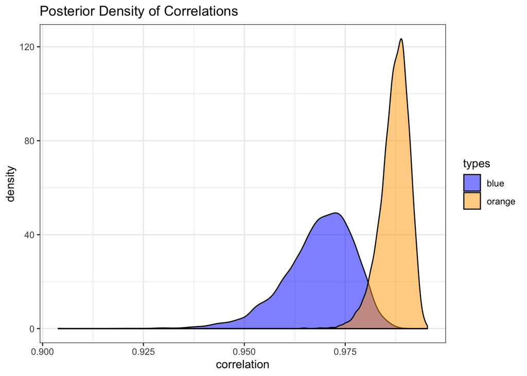

```r
corr = data.frame(correlation = c(corr_blue, corr_orange), types = rep(c("blue", "orange"), each = S))

ggplot(corr, aes(x = correlation, fill = types)) +
  geom_density(alpha = 0.5) +
  scale_fill_manual(values = c("blue", "orange")) +
  ggtitle("Posterior Density of Correlations")
```

From the plot above we can find that the correlation of body depth and rear width in blue crabs are smaller than the correlation in orange crabs with a high probability. Also, the spread (variance) of correlation in blue crabs is larger than the one in orange crabs.

```r
diff_bo = mean(corr_blue < corr_orange)
diff_bo
```

```
## [1] 0.9896
```

$\text{Pr}(\rho_{\text{blue}} < \rho_{\text{orange}} | \mathbf y_{\text{blue}}, \mathbf y_{\text{orange}}) = 0.9896$. All these results suggest that the $\rho_{\text{blue}} < \rho_{\text{orange}}$ is true for almost for every sample. Orange crabs have a greater correlation between body depth and rear width than blue crabs.